# Lecture 13 - Attention and impulsivity

# Background & ADHD

## Living with ADHD

[video not shown]

## ADHD

- Attention Deficit/Hyperactivity Disorder (ADHD) is defined by a combination of symptoms of
  - Inattention
  - Hyperactivity/impulsivity
- 3 types:

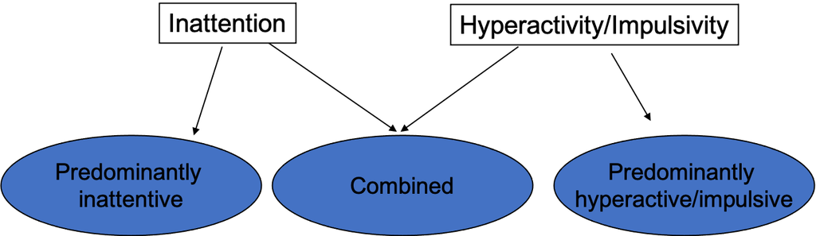

## Diagnosis

- Six (or more) of the following symptoms of inattention or hyperactivity-impulsivity have persisted for at least 6 months to a degree that is maladaptive and inconsistent with developmental level. Some examples as follows:
- Inattention
  - Often does not give close attention to details or makes careless mistakes in schoolwork.
  - Often has trouble keeping attention on tasks or play activities.
  - Often does not seem to listen when spoken to directly.
- Hyperactivity-impulsivity
  - Often fidgets with hands or feet or squirms in seat.
  - Often gets up from seat when remaining in seat is expected.
  - Often runs about or climbs when and where it is not appropriate.

## Features

- Peak onset between the age of 3 and 4
- Affects 3%-5% children, prevalence higher in areas of socio-economic disadvantage
- Male/Female ratio
  - 4:1 for the hyperactivity/impulsivity type
  - 2:1 for the inattention type
- Co-morbidity: 50% of the children also show another psychiatric disorder:
  - Learning difficulties, Oppositional Defiant Disorder and Conduct Disorder, Anxiety and mood disorders, Substance abuse, Tic disorders
- Medical/Physical characteristics:
  - More accident prone, Sleep problems
  - Persists in adolescence for around 50-80% of individuals and in adulthood for around 30-50% of individuals

## Genetics

- Disorder clusters in families
  - Increased risk for 1st and 2nd order degree relatives (Faraone et al. 1995)
  - Siblings are 3 to 5 times more at risk (Biederman et al., 1992, Faraone et al., 1993)
  - Concordance is higher in monozygotic twins (50%-80%) than dizygotic twins (33%) (Bradley & Golden, 2001)

Several candidate genes (Durston & Konrad, 2007), some linked to dopaminergic system and others to the serotonergic system. Likely to have a complex genetic origin

## Cold vs hot executive tasks

- “Cold” executive functions tasks are associated with working memory, inhibition and planning.
- “Hot” executive function tasks are associated with reward and reinforcement mechanisms

## Stroop task

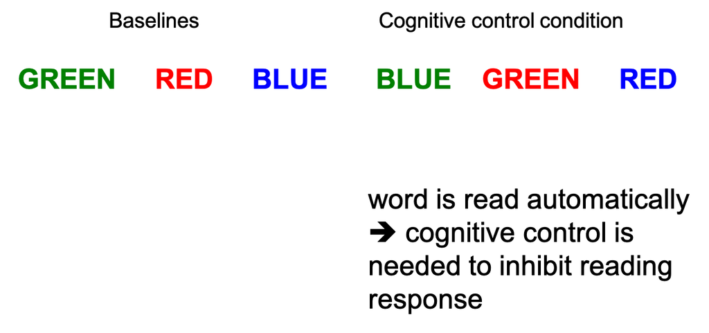

## Stroop task processes

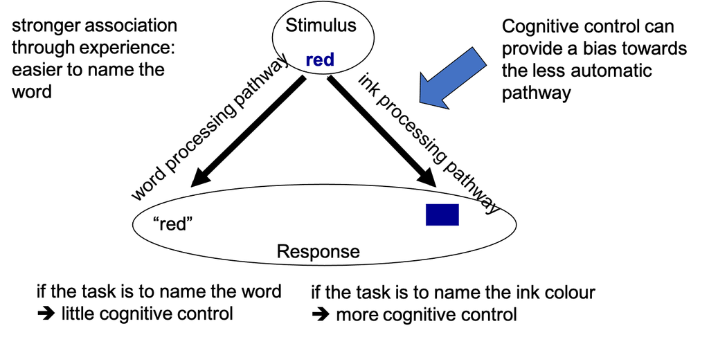

## Delay aversion

- Greater preference for smaller-immediate over larger-delayed rewards (choice impulsivity)
- 1CHF now or 100 CHF in a year?
  - At which point do you shift your choice?
- Marshmallow test for kids. One now or two later?

## Marshmallow test

[video not shown]

# Performance on executive function tasks

- Behavioural evidence
- fMRI evidence

## Behavioural evidence

- Review of 8 meta-analyses:
  - Large effect: >0.50
  - Medium effect: 0.50-0.30
  - Small effect: <0.30

(Nigg, 2005)

## Nigg 2005 results

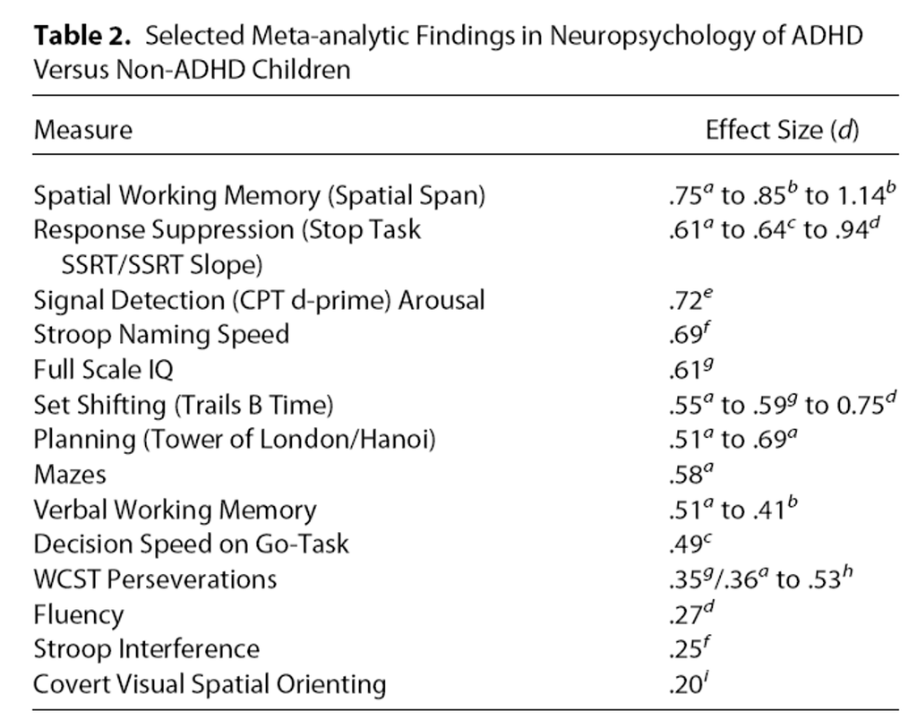

## Nigg 2005 results

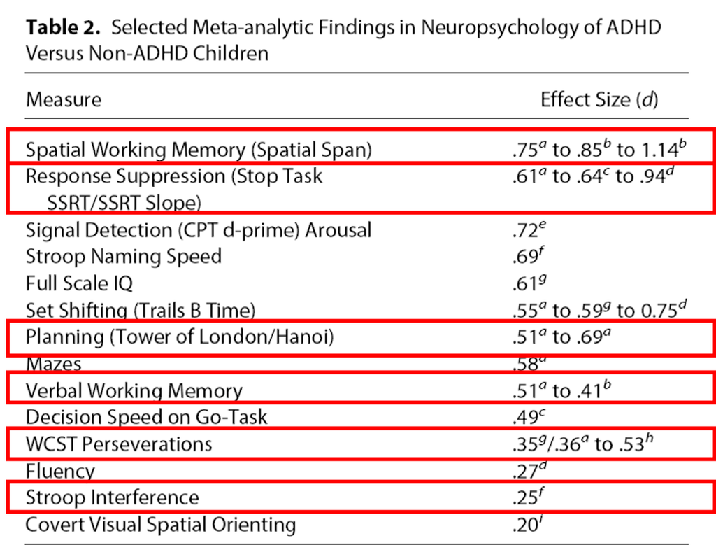

## Neurobiological evidence

- Functional MRI studies reveal atypical activity in
  - Prefrontal cortex (esp. right inferior frontal)
  - Basal ganglia (esp. putamen)
  - Cerebellum
  - Parietal areas

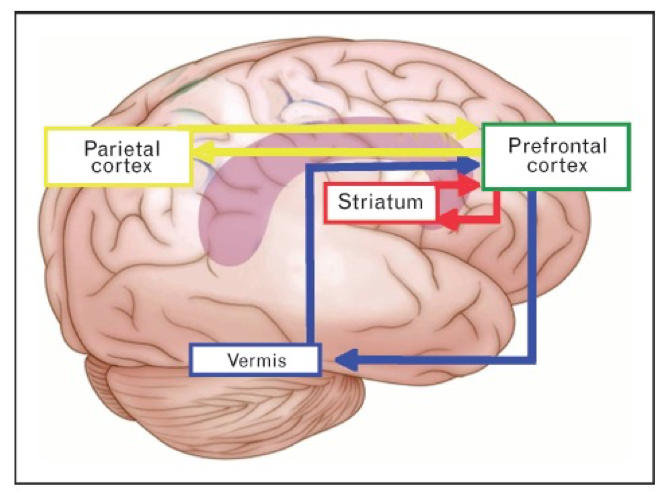

(Casey & Durston, 2006; Rubia, 2018)

## Response suppression task

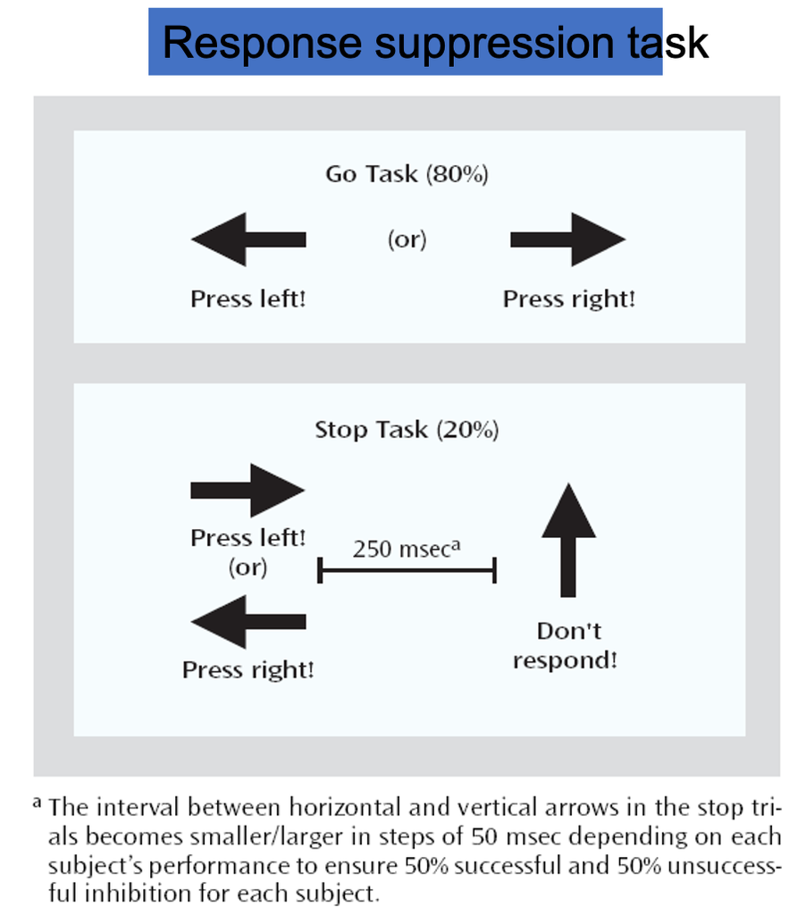

(Rubia et al., 2005; Rubia, 2018)

## Response suppression results

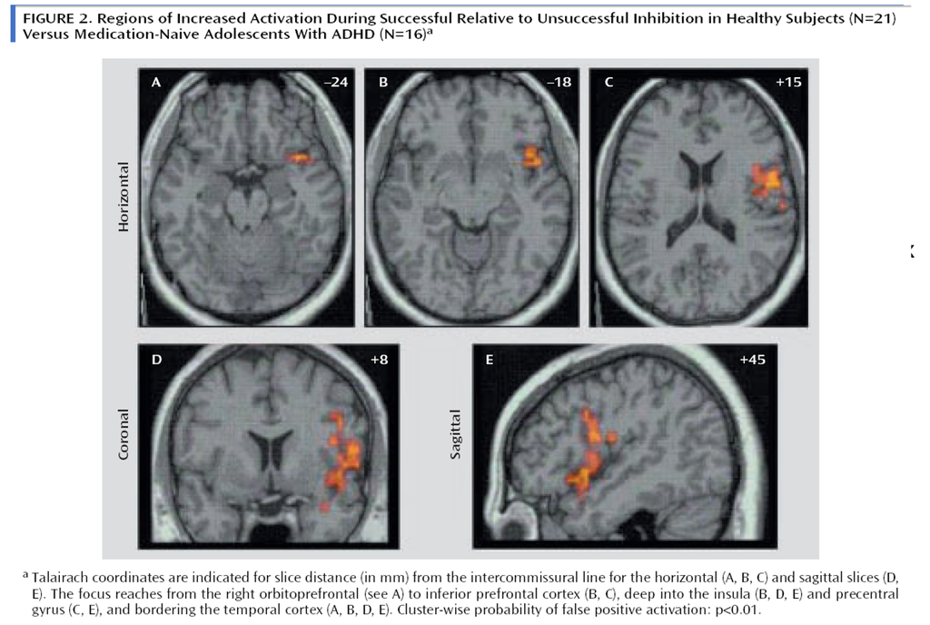

(Rubia et al., 2005; Rubia, 2018)

## “Cold” task summary

Individuals with ADHD show:

- Atypical performance in EF tasks
- Atypical neural responses compared to controls in “cold” EF tasks
- What about “hot” tasks?

## Reward task

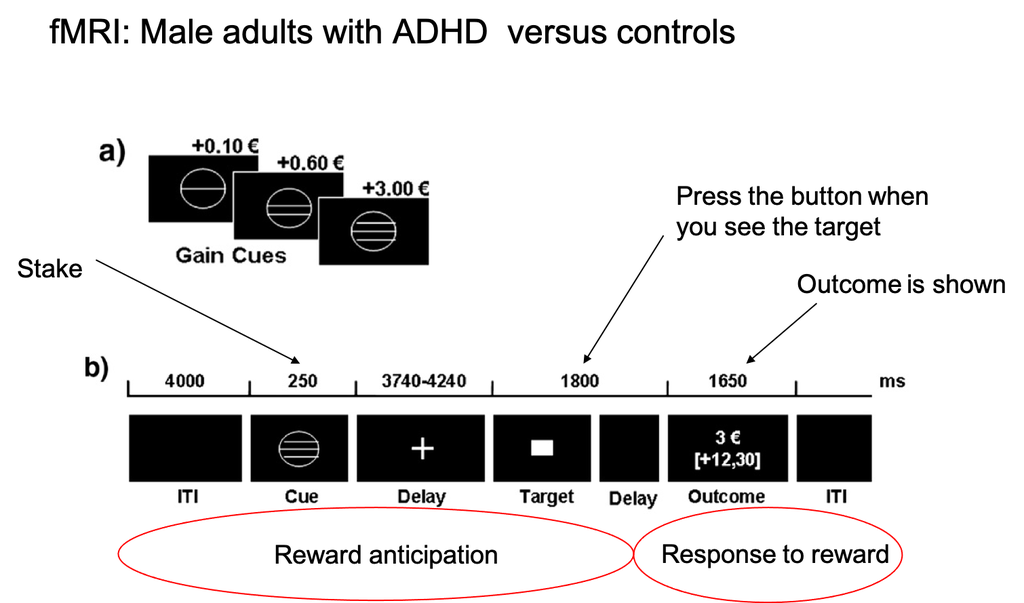

(Ströhle et al., 2008)

## Reward results

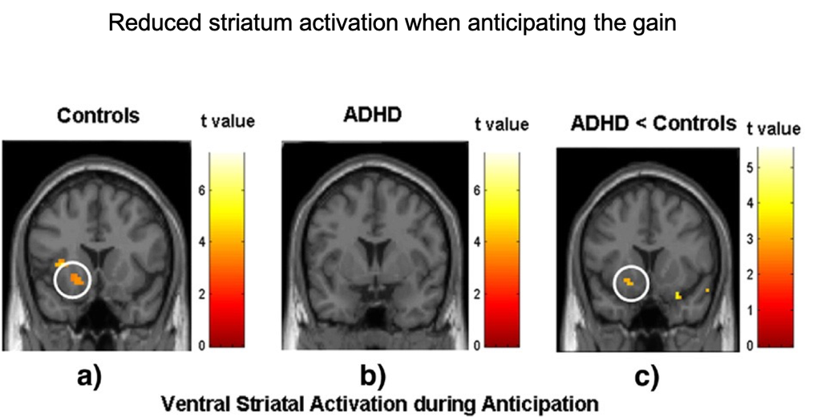

(Ströhle et al., 2008)

## Reward results

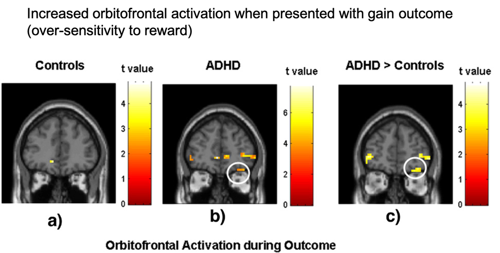

(Ströhle et al., 2008)

## Summary

Individuals with ADHD show:

- Atypical performance in EF tasks
- Atypical neural responses compared to controls in “cold” and “hot” EF tasks

However…

## Individual differences - Nigg 2005

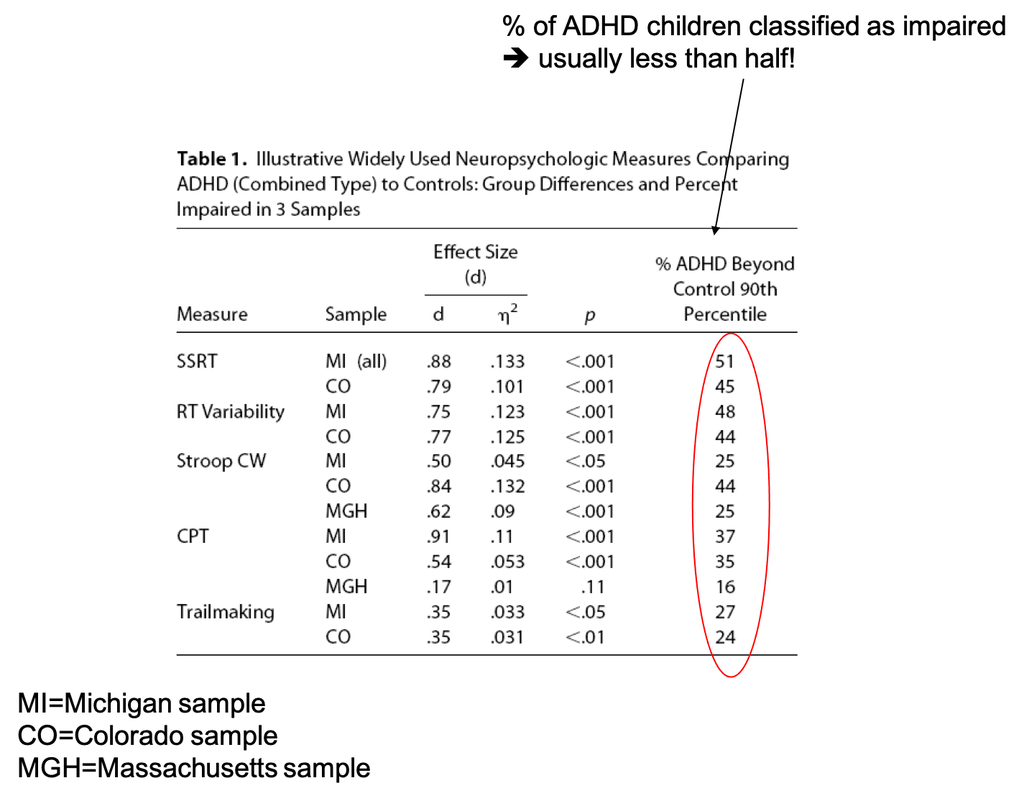

## Individual differences

When ADHD children tested on both inhibition and delay aversion and looking at individual performances rather than group performance:

- 23% deficit on both
- 23% inhibition deficit only
- 15% delay aversion deficit only
- 39% no apparent deficit on any of the two

So what does this mean?

(Nigg, 2005)

## Single cognitive mechanism?

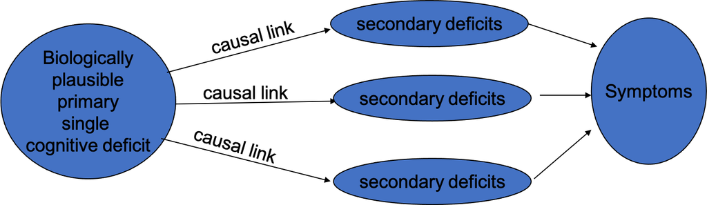

## Inhibition

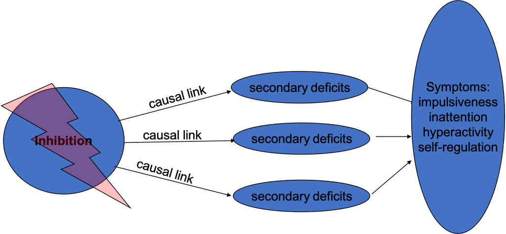

## Reward

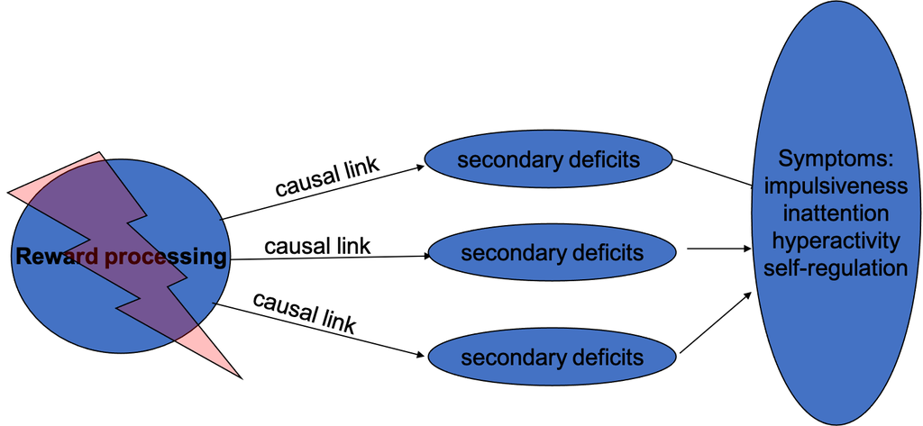

## Future research

- Is there good evidence for a single cognitive deficit hypothesis?
- How well does a deficit in inhibition or motivation/reward processing explain the clinical symptoms associated with ADHD?
- Is it plausible to assume a single core deficit? What are the alternative options? And what are the implications for designing effective interventions?

(Castellanos et al., 2006; Rubia, 2018; Sonuga-Barke, 2005)

# Take a break

# Part 2 - Read and discuss

## Discussion material

- break into small groups (~ 5 per group)
- discuss aspects of the lecture
- discuss aspects of the journal article: [Rubia, 2018](https://www.frontiersin.org/journals/human-neuroscience/articles/10.3389/fnhum.2018.00100/full)
- There is no need to read all of the paper. Pick a section of the paper that interests you and focus on that for the discussion.

## References

Casey, B. j., & Durston, Ph. d., Sarah. (2006). From Behavior to Cognition to the Brain and Back: What Have We Learned From Functional Imaging Studies of Attention Deficit Hyperactivity Disorder? *American Journal of Psychiatry*, *163*(6), 957–960. https://doi.org/10.1176/ajp.2006.163.6.957

Castellanos, F. X., Sonuga-Barke, E. J. S., Milham, M. P., & Tannock, R. (2006). Characterizing cognition in ADHD: Beyond executive dysfunction. *Trends in Cognitive Sciences*, *10*(3), 117–123. https://doi.org/10.1016/j.tics.2006.01.011

Nigg, J. T. (2005). Neuropsychologic Theory and Findings in Attention-Deficit/Hyperactivity Disorder: The State of the Field and Salient Challenges for the Coming Decade. *Biological Psychiatry*, *57*(11), 1424–1435. https://doi.org/10.1016/j.biopsych.2004.11.011

Rubia, K. (2018). Cognitive Neuroscience of Attention Deficit Hyperactivity Disorder (ADHD) and Its Clinical Translation. *Frontiers in Human Neuroscience*, *12*. https://doi.org/10.3389/fnhum.2018.00100

Rubia, K., Smith, A. B., Brammer, M. J., Toone, B., & Taylor, E. (2005). Abnormal Brain Activation During Inhibition and Error Detection in Medication-Naive Adolescents With ADHD. *American Journal of Psychiatry*. https://doi.org/10.1176/appi.ajp.162.6.1067

Sonuga-Barke, E. J. S. (2005). Causal Models of Attention-Deficit/Hyperactivity Disorder: From Common Simple Deficits to Multiple Developmental Pathways. *Biological Psychiatry*, *57*(11), 1231–1238. https://doi.org/10.1016/j.biopsych.2004.09.008

Ströhle, A., Stoy, M., Wrase, J., Schwarzer, S., Schlagenhauf, F., Huss, M., Hein, J., Nedderhut, A., Neumann, B., Gregor, A., Juckel, G., Knutson, B., Lehmkuhl, U., Bauer, M., & Heinz, A. (2008). Reward anticipation and outcomes in adult males with attention-deficit/hyperactivity disorder. *NeuroImage*, *39*(3), 966–972. https://doi.org/10.1016/j.neuroimage.2007.09.044

## Acknowledgements

- Unless otherwise specified, icons and images were used under license from [The Noun Project](https://thenounproject.com/)
- Slides were created with [Quarto](https://quarto.org/) and [RevealJS](https://revealjs.com/)